# Candy Clean-up

David Rucinski

2019 December 8th

## Objective

Clean up this somewhat messy data, and try some html stylizing.

Variable names have square brackets, I would like to remove that and any column with too much missing data.

The ‘Age’ variable had all of its input as a **character/string** class/type and thus not numeric. With no limit people had answered with “old enough” , “too old” , “>39” , “-” , “30+” , “37,” , or even three pages worth in digits of pi. With no uniform way to correct it, this was the main problem to solve.

## Packages

```r
library(data.table)
library(ggplot2)
library(dplyr)
library(plyr) # revalue()

library(readxl)
library(DataExplorer) #Mhm

library(kableExtra)
```

## Cleaning Data

**Note: this is a tab bar**

### Data

[CandayData-2015.xlsx](https://raw.githubusercontent.com/DavidRucinski/Heart_health/master/Candy/CandyData-2015.xlsx)

Let’s take a look at the data, see what columns we have.

```r
# CandyData_2014 <- read_excel("CandyData-2014.xlsx")
# glimpse(CandyData_2014)
#
# tail(CandyData_2014)
# CandyData_2014 <- CandyData_2014[-87,] #Last row looks to be the total, may use this for proportions but for now, out.
#
# names(CandyData_2014)


CandyData_2015 <- read_excel("CandyData-2015.xlsx")
head(names(CandyData_2015), 7)
```

```
## [1] "Timestamp"
## [2] "How old are you?"
## [3] "Are you going actually going trick or treating yourself?"
## [4] "[Butterfinger]"
## [5] "[100 Grand Bar]"
## [6] "[Anonymous brown globs that come in black and orange wrappers]"
## [7] "[Any full-sized candy bar]"
```

```r
tail(names(CandyData_2015), 7)
```

```
## [1] "Please estimate the degrees of separation you have from the following folks [JK Rowling]"
## [2] "Please estimate the degrees of separation you have from the following folks [Malala Yousafzai]"
## [3] "Please estimate the degrees of separation you have from the following folks [Thom Yorke]"
## [4] "Please estimate the degrees of separation you have from the following folks [JJ Abrams]"
## [5] "Please estimate the degrees of separation you have from the following folks [Hillary Clinton]"
## [6] "Please estimate the degrees of separation you have from the following folks [Donald Trump]"
## [7] "Please estimate the degrees of separation you have from the following folks [Beyoncé Knowles]"
```

```r
length(names(CandyData_2015))
```

```
## [1] 124
```

We got 124 variables. All the columns that have square brackets will be annoying to refer to, they also look a bit messy in the output. Let’s adjust this by just removing them.

### Preprocessing

```r
# Removing '[]' from variable names since it will be a pain to refer to them
colnames(CandyData_2015) <- gsub("\\[|\\]", "", names(CandyData_2015))
head(names(CandyData_2015), 7)
```

```
## [1] "Timestamp"
## [2] "How old are you?"
## [3] "Are you going actually going trick or treating yourself?"
## [4] "Butterfinger"
## [5] "100 Grand Bar"
## [6] "Anonymous brown globs that come in black and orange wrappers"
## [7] "Any full-sized candy bar"
```

```r
tail(names(CandyData_2015), 7)
```

```
## [1] "Please estimate the degrees of separation you have from the following folks JK Rowling"
## [2] "Please estimate the degrees of separation you have from the following folks Malala Yousafzai"
## [3] "Please estimate the degrees of separation you have from the following folks Thom Yorke"
## [4] "Please estimate the degrees of separation you have from the following folks JJ Abrams"
## [5] "Please estimate the degrees of separation you have from the following folks Hillary Clinton"
## [6] "Please estimate the degrees of separation you have from the following folks Donald Trump"
## [7] "Please estimate the degrees of separation you have from the following folks Beyoncé Knowles"
```

That looks better. Let’s take a look at the structure of our data and then onto the first variable (ignoring the timestamp), ‘How old are you?’ to see what kind of values we have.

A scrollable window for the first 50 records

```r
knitr::kable(head(CandyData_2015, 50)) %>%
  kable_styling(bootstrap_options = c("striped", "hover")) %>%
  scroll_box(width = "900px", height = "600px")
```

| Timestamp | How old are you? | Are you going actually going trick or treating yourself? | Butterfinger | 100 Grand Bar | Anonymous brown globs that come in black and orange wrappers | Any full-sized candy bar | Black Jacks | Bonkers | Bottle Caps | Box’o’ Raisins | Brach products (not including candy corn) | Bubble Gum | Cadbury Creme Eggs | Candy Corn | Vials of pure high fructose corn syrup, for main-lining into your vein | Candy that is clearly just the stuff given out for free at restaurants | Cash, or other forms of legal tender | Chiclets | Caramellos | Snickers | Dark Chocolate Hershey | Dental paraphenalia | Dots | Fuzzy Peaches | Generic Brand Acetaminophen | Glow sticks | Broken glow stick | Goo Goo Clusters | Good N’ Plenty | … |
| --- | --- | --- | --- | --- | --- | --- | --- | --- | --- | --- | --- | --- | --- | --- | --- | --- | --- | --- | --- | --- | --- | --- | --- | --- | --- | --- | --- | --- | --- | --- |
| 2015-10-23 08:46:20 | 35.0 | No | JOY | NA | DESPAIR | JOY | NA | NA | NA | NA | DESPAIR | DESPAIR | DESPAIR | NA | DESPAIR | DESPAIR | JOY | NA | NA | JOY | JOY | DESPAIR | JOY | DESPAIR | DESPAIR | DESPAIR | DESPAIR | NA | DESPAIR | … |
| 2015-10-23 08:46:51 | 41.0 | No | JOY | JOY | DESPAIR | JOY | DESPAIR | DESPAIR | JOY | DESPAIR | DESPAIR | DESPAIR | DESPAIR | DESPAIR | DESPAIR | DESPAIR | JOY | DESPAIR | DESPAIR | JOY | DESPAIR | DESPAIR | JOY | DESPAIR | JOY | JOY | DESPAIR | DESPAIR | DESPAIR | … |
| 2015-10-23 08:47:34 | 33.0 | No | DESPAIR | DESPAIR | DESPAIR | JOY | DESPAIR | DESPAIR | DESPAIR | JOY | DESPAIR | DESPAIR | JOY | JOY | DESPAIR | DESPAIR | JOY | DESPAIR | JOY | JOY | JOY | DESPAIR | DESPAIR | DESPAIR | DESPAIR | DESPAIR | DESPAIR | DESPAIR | DESPAIR | … |
| 2015-10-23 08:47:58 | 31.0 | No | JOY | JOY | DESPAIR | JOY | DESPAIR | DESPAIR | JOY | DESPAIR | DESPAIR | DESPAIR | DESPAIR | DESPAIR | DESPAIR | DESPAIR | JOY | DESPAIR | JOY | JOY | JOY | DESPAIR | DESPAIR | DESPAIR | DESPAIR | JOY | DESPAIR | JOY | DESPAIR | … |
| 2015-10-23 08:48:11 | 30.0 | No | NA | JOY | DESPAIR | JOY | NA | NA | NA | NA | NA | NA | NA | NA | NA | NA | JOY | NA | JOY | NA | NA | NA | JOY | JOY | NA | JOY | NA | NA | NA | … |
| 2015-10-23 08:49:06 | 38.0 | No | JOY | JOY | DESPAIR | JOY | DESPAIR | JOY | JOY | DESPAIR | JOY | DESPAIR | DESPAIR | DESPAIR | JOY | DESPAIR | JOY | JOY | JOY | DESPAIR | DESPAIR | DESPAIR | JOY | JOY | DESPAIR | JOY | DESPAIR | JOY | JOY | … |
| 2015-10-23 08:50:08 | 48.0 | No | JOY | JOY | DESPAIR | JOY | JOY | DESPAIR | JOY | DESPAIR | DESPAIR | DESPAIR | DESPAIR | DESPAIR | DESPAIR | DESPAIR | JOY | DESPAIR | JOY | JOY | JOY | DESPAIR | DESPAIR | JOY | DESPAIR | JOY | DESPAIR | DESPAIR | JOY | … |
| 2015-10-23 08:52:14 | 39.0 | No | DESPAIR | JOY | DESPAIR | NA | NA | NA | JOY | NA | NA | NA | DESPAIR | NA | DESPAIR | DESPAIR | JOY | JOY | JOY | JOY | NA | JOY | NA | JOY | NA | JOY | DESPAIR | JOY | DESPAIR | … |
| 2015-10-23 08:52:22 | 9.0E22 | Yes | DESPAIR | DESPAIR | DESPAIR | DESPAIR | DESPAIR | DESPAIR | DESPAIR | DESPAIR | DESPAIR | DESPAIR | DESPAIR | JOY | DESPAIR | DESPAIR | DESPAIR | DESPAIR | DESPAIR | DESPAIR | DESPAIR | DESPAIR | DESPAIR | DESPAIR | DESPAIR | DESPAIR | DESPAIR | DESPAIR | DESPAIR | … |
| 2015-10-23 08:53:30 | 54.0 | No | JOY | JOY | DESPAIR | JOY | JOY | DESPAIR | JOY | DESPAIR | DESPAIR | DESPAIR | JOY | DESPAIR | JOY | DESPAIR | JOY | DESPAIR | JOY | JOY | JOY | DESPAIR | JOY | DESPAIR | DESPAIR | JOY | DESPAIR | DESPAIR | JOY | … |
| 2015-10-23 08:54:15 | 40.0 | No | JOY | JOY | DESPAIR | JOY | DESPAIR | JOY | JOY | DESPAIR | DESPAIR | JOY | DESPAIR | JOY | DESPAIR | DESPAIR | JOY | JOY | JOY | JOY | JOY | DESPAIR | JOY | JOY | DESPAIR | JOY | DESPAIR | JOY | DESPAIR | … |
| 2015-10-23 08:54:15 | 38.0 | No | JOY | JOY | JOY | JOY | DESPAIR | DESPAIR | DESPAIR | DESPAIR | JOY | DESPAIR | DESPAIR | DESPAIR | DESPAIR | DESPAIR | JOY | DESPAIR | JOY | JOY | JOY | DESPAIR | DESPAIR | DESPAIR | DESPAIR | DESPAIR | DESPAIR | DESPAIR | DESPAIR | … |
| 2015-10-23 08:54:56 | 33.0 | No | JOY | JOY | DESPAIR | JOY | DESPAIR | DESPAIR | DESPAIR | DESPAIR | DESPAIR | NA | JOY | NA | DESPAIR | DESPAIR | JOY | JOY | JOY | JOY | JOY | DESPAIR | DESPAIR | DESPAIR | DESPAIR | DESPAIR | DESPAIR | JOY | DESPAIR | … |
| 2015-10-23 08:55:00 | 36.0 | No | JOY | JOY | DESPAIR | JOY | DESPAIR | JOY | DESPAIR | DESPAIR | NA | NA | JOY | DESPAIR | DESPAIR | DESPAIR | JOY | JOY | JOY | JOY | JOY | DESPAIR | JOY | DESPAIR | DESPAIR | JOY | DESPAIR | DESPAIR | DESPAIR | … |
| 2015-10-23 08:55:06 | 47.0 | No | JOY | NA | DESPAIR | NA | NA | NA | NA | DESPAIR | NA | DESPAIR | JOY | JOY | NA | DESPAIR | NA | DESPAIR | JOY | JOY | NA | DESPAIR | NA | NA | NA | JOY | DESPAIR | NA | DESPAIR | … |
| 2015-10-23 08:56:20 | 60.0 | Yes | DESPAIR | JOY | DESPAIR | JOY | DESPAIR | DESPAIR | DESPAIR | JOY | JOY | JOY | JOY | JOY | DESPAIR | DESPAIR | JOY | JOY | JOY | JOY | JOY | DESPAIR | DESPAIR | JOY | DESPAIR | JOY | DESPAIR | DESPAIR | JOY | … |
| 2015-10-23 08:56:25 | 34.0 | No | JOY | JOY | DESPAIR | JOY | DESPAIR | DESPAIR | DESPAIR | DESPAIR | DESPAIR | DESPAIR | JOY | JOY | DESPAIR | DESPAIR | JOY | DESPAIR | JOY | JOY | JOY | DESPAIR | DESPAIR | DESPAIR | DESPAIR | DESPAIR | DESPAIR | DESPAIR | DESPAIR | … |
| 2015-10-23 08:57:21 | 44.0 | Yes | JOY | DESPAIR | JOY | JOY | DESPAIR | JOY | DESPAIR | DESPAIR | DESPAIR | DESPAIR | JOY | DESPAIR | DESPAIR | DESPAIR | JOY | JOY | JOY | JOY | JOY | DESPAIR | JOY | JOY | DESPAIR | DESPAIR | JOY | NA | JOY | … |
| 2015-10-23 08:57:58 | 46.0 | No | JOY | JOY | DESPAIR | JOY | DESPAIR | DESPAIR | JOY | DESPAIR | DESPAIR | DESPAIR | DESPAIR | JOY | DESPAIR | DESPAIR | JOY | DESPAIR | DESPAIR | JOY | JOY | DESPAIR | DESPAIR | DESPAIR | DESPAIR | DESPAIR | DESPAIR | DESPAIR | NA | … |
| 2015-10-23 08:58:14 | 34.0 | No | JOY | JOY | DESPAIR | JOY | DESPAIR | NA | JOY | DESPAIR | DESPAIR | DESPAIR | DESPAIR | DESPAIR | DESPAIR | DESPAIR | JOY | DESPAIR | JOY | JOY | JOY | DESPAIR | NA | DESPAIR | DESPAIR | JOY | JOY | DESPAIR | DESPAIR | … |
| 2015-10-23 08:58:41 | 46.0 | No | JOY | JOY | DESPAIR | JOY | DESPAIR | DESPAIR | JOY | DESPAIR | DESPAIR | DESPAIR | DESPAIR | JOY | DESPAIR | DESPAIR | JOY | DESPAIR | DESPAIR | JOY | JOY | DESPAIR | DESPAIR | DESPAIR | DESPAIR | DESPAIR | DESPAIR | DESPAIR | NA | … |
| 2015-10-23 08:59:19 | 47.0 | No | JOY | DESPAIR | JOY | JOY | DESPAIR | JOY | JOY | DESPAIR | DESPAIR | DESPAIR | JOY | JOY | DESPAIR | DESPAIR | DESPAIR | DESPAIR | DESPAIR | JOY | DESPAIR | DESPAIR | DESPAIR | JOY | DESPAIR | DESPAIR | DESPAIR | DESPAIR | JOY | … |
| 2015-10-23 08:59:39 | 52.0 | No | JOY | JOY | DESPAIR | JOY | DESPAIR | DESPAIR | DESPAIR | DESPAIR | DESPAIR | DESPAIR | DESPAIR | DESPAIR | DESPAIR | DESPAIR | DESPAIR | DESPAIR | DESPAIR | DESPAIR | JOY | DESPAIR | JOY | DESPAIR | DESPAIR | DESPAIR | DESPAIR | JOY | JOY | … |
| 2015-10-23 09:00:13 | 38.0 | No | JOY | DESPAIR | DESPAIR | JOY | DESPAIR | JOY | JOY | JOY | DESPAIR | DESPAIR | DESPAIR | DESPAIR | DESPAIR | DESPAIR | JOY | JOY | DESPAIR | JOY | JOY | JOY | JOY | JOY | DESPAIR | DESPAIR | DESPAIR | DESPAIR | DESPAIR | … |
| 2015-10-23 09:00:23 | 33.0 | No | JOY | JOY | DESPAIR | JOY | DESPAIR | DESPAIR | DESPAIR | DESPAIR | DESPAIR | DESPAIR | JOY | DESPAIR | DESPAIR | DESPAIR | JOY | DESPAIR | JOY | JOY | DESPAIR | DESPAIR | DESPAIR | DESPAIR | DESPAIR | JOY | DESPAIR | DESPAIR | DESPAIR | … |
| 2015-10-23 09:00:41 | 44.0 | No | JOY | JOY | DESPAIR | JOY | DESPAIR | DESPAIR | JOY | DESPAIR | JOY | JOY | JOY | DESPAIR | DESPAIR | DESPAIR | JOY | JOY | JOY | JOY | JOY | DESPAIR | DESPAIR | DESPAIR | DESPAIR | JOY | DESPAIR | JOY | JOY | … |
| 2015-10-23 09:00:54 | 37.0 | No | JOY | JOY | DESPAIR | JOY | NA | NA | NA | DESPAIR | NA | DESPAIR | DESPAIR | JOY | JOY | DESPAIR | JOY | DESPAIR | JOY | JOY | JOY | DESPAIR | NA | NA | NA | JOY | DESPAIR | NA | NA | … |
| 2015-10-23 09:01:35 | 33.0 | No | NA | NA | DESPAIR | JOY | NA | NA | NA | JOY | DESPAIR | DESPAIR | JOY | JOY | NA | NA | JOY | DESPAIR | JOY | DESPAIR | JOY | NA | JOY | DESPAIR | NA | JOY | DESPAIR | DESPAIR | DESPAIR | … |
| 2015-10-23 09:01:47 | 57.0 | No | JOY | NA | DESPAIR | JOY | DESPAIR | NA | NA | DESPAIR | NA | NA | JOY | JOY | NA | DESPAIR | JOY | DESPAIR | NA | JOY | NA | DESPAIR | JOY | JOY | NA | JOY | DESPAIR | JOY | DESPAIR | … |
| 2015-10-23 09:01:51 | 32.0 | No | DESPAIR | JOY | DESPAIR | JOY | DESPAIR | JOY | JOY | DESPAIR | DESPAIR | DESPAIR | JOY | DESPAIR | JOY | DESPAIR | DESPAIR | DESPAIR | JOY | JOY | JOY | DESPAIR | DESPAIR | JOY | JOY | JOY | DESPAIR | JOY | DESPAIR | … |
| 2015-10-23 09:02:17 | 45.0 | No | JOY | JOY | DESPAIR | JOY | DESPAIR | DESPAIR | JOY | DESPAIR | DESPAIR | DESPAIR | JOY | DESPAIR | DESPAIR | DESPAIR | JOY | DESPAIR | JOY | JOY | JOY | DESPAIR | DESPAIR | JOY | DESPAIR | JOY | DESPAIR | JOY | JOY | … |
| 2015-10-23 09:02:29 | 38.0 | No | DESPAIR | NA | NA | JOY | DESPAIR | DESPAIR | DESPAIR | DESPAIR | DESPAIR | DESPAIR | JOY | JOY | JOY | DESPAIR | JOY | DESPAIR | JOY | DESPAIR | JOY | DESPAIR | DESPAIR | DESPAIR | DESPAIR | DESPAIR | DESPAIR | DESPAIR | DESPAIR | … |
| 2015-10-23 09:02:30 | 58.0 | Yes | JOY | JOY | DESPAIR | JOY | DESPAIR | DESPAIR | DESPAIR | DESPAIR | DESPAIR | DESPAIR | JOY | JOY | DESPAIR | DESPAIR | JOY | DESPAIR | DESPAIR | JOY | JOY | DESPAIR | DESPAIR | DESPAIR | DESPAIR | JOY | DESPAIR | DESPAIR | JOY | … |
| 2015-10-23 09:03:50 | 43.0 | No | DESPAIR | JOY | DESPAIR | JOY | DESPAIR | DESPAIR | DESPAIR | DESPAIR | DESPAIR | JOY | JOY | DESPAIR | JOY | DESPAIR | JOY | JOY | JOY | JOY | JOY | DESPAIR | DESPAIR | DESPAIR | DESPAIR | JOY | DESPAIR | DESPAIR | DESPAIR | … |
| 2015-10-23 09:04:38 | 45.0 | Yes | JOY | JOY | DESPAIR | JOY | DESPAIR | NA | NA | NA | NA | JOY | NA | DESPAIR | DESPAIR | DESPAIR | JOY | JOY | JOY | JOY | NA | NA | DESPAIR | NA | DESPAIR | JOY | DESPAIR | JOY | DESPAIR | … |
| 2015-10-23 09:05:03 | 60.0 | No | JOY | DESPAIR | DESPAIR | JOY | DESPAIR | DESPAIR | DESPAIR | DESPAIR | DESPAIR | DESPAIR | JOY | DESPAIR | DESPAIR | DESPAIR | JOY | DESPAIR | DESPAIR | JOY | JOY | DESPAIR | DESPAIR | DESPAIR | DESPAIR | JOY | DESPAIR | DESPAIR | DESPAIR | … |
| 2015-10-23 09:05:17 | NA | No | JOY | JOY | DESPAIR | JOY | DESPAIR | DESPAIR | DESPAIR | DESPAIR | DESPAIR | JOY | JOY | DESPAIR | DESPAIR | DESPAIR | JOY | JOY | JOY | JOY | DESPAIR | DESPAIR | DESPAIR | DESPAIR | DESPAIR | JOY | DESPAIR | DESPAIR | DESPAIR | … |
| 2015-10-23 09:05:32 | 49.0 | No | DESPAIR | JOY | DESPAIR | JOY | DESPAIR | DESPAIR | DESPAIR | DESPAIR | DESPAIR | DESPAIR | JOY | DESPAIR | JOY | DESPAIR | DESPAIR | DESPAIR | DESPAIR | JOY | JOY | DESPAIR | DESPAIR | DESPAIR | DESPAIR | DESPAIR | DESPAIR | DESPAIR | DESPAIR | … |
| 2015-10-23 09:05:42 | 34.0 | No | JOY | JOY | DESPAIR | JOY | DESPAIR | DESPAIR | DESPAIR | DESPAIR | DESPAIR | DESPAIR | JOY | DESPAIR | DESPAIR | DESPAIR | JOY | DESPAIR | DESPAIR | JOY | JOY | DESPAIR | JOY | DESPAIR | DESPAIR | JOY | DESPAIR | DESPAIR | DESPAIR | … |
| 2015-10-23 09:06:38 | NA | No | JOY | NA | DESPAIR | JOY | NA | NA | JOY | DESPAIR | NA | NA | JOY | DESPAIR | NA | DESPAIR | JOY | JOY | NA | JOY | JOY | DESPAIR | NA | JOY | NA | NA | NA | NA | NA | … |
| 2015-10-23 09:07:14 | 36.0 | No | JOY | JOY | DESPAIR | JOY | NA | NA | NA | DESPAIR | NA | NA | JOY | DESPAIR | NA | NA | JOY | DESPAIR | JOY | JOY | JOY | NA | NA | NA | DESPAIR | NA | DESPAIR | JOY | DESPAIR | … |
| 2015-10-23 09:07:30 | 47.0 | No | JOY | DESPAIR | DESPAIR | JOY | DESPAIR | DESPAIR | DESPAIR | DESPAIR | DESPAIR | DESPAIR | DESPAIR | JOY | JOY | DESPAIR | DESPAIR | DESPAIR | DESPAIR | DESPAIR | JOY | DESPAIR | JOY | DESPAIR | DESPAIR | JOY | DESPAIR | JOY | DESPAIR | … |
| 2015-10-23 09:07:44 | 52.0 | No | JOY | JOY | DESPAIR | JOY | DESPAIR | DESPAIR | DESPAIR | DESPAIR | DESPAIR | JOY | DESPAIR | DESPAIR | DESPAIR | DESPAIR | JOY | JOY | DESPAIR | JOY | JOY | JOY | DESPAIR | JOY | DESPAIR | JOY | DESPAIR | DESPAIR | JOY | … |
| 2015-10-23 09:08:07 | 30.0 | No | JOY | JOY | DESPAIR | JOY | DESPAIR | DESPAIR | DESPAIR | DESPAIR | DESPAIR | DESPAIR | DESPAIR | DESPAIR | DESPAIR | DESPAIR | DESPAIR | DESPAIR | DESPAIR | JOY | JOY | DESPAIR | DESPAIR | JOY | DESPAIR | DESPAIR | DESPAIR | DESPAIR | DESPAIR | … |
| 2015-10-23 09:08:25 | 54.0 | No | JOY | JOY | DESPAIR | JOY | NA | NA | JOY | DESPAIR | NA | NA | JOY | NA | NA | NA | JOY | NA | JOY | JOY | JOY | DESPAIR | NA | NA | NA | JOY | NA | NA | NA | … |
| 2015-10-23 09:09:13 | 64.0 | No | DESPAIR | JOY | DESPAIR | JOY | DESPAIR | DESPAIR | DESPAIR | DESPAIR | DESPAIR | DESPAIR | DESPAIR | JOY | DESPAIR | DESPAIR | JOY | JOY | JOY | DESPAIR | JOY | DESPAIR | JOY | DESPAIR | DESPAIR | DESPAIR | DESPAIR | JOY | JOY | … |
| 2015-10-23 09:09:18 | 26.0 | No | JOY | JOY | DESPAIR | JOY | DESPAIR | JOY | JOY | DESPAIR | DESPAIR | JOY | JOY | JOY | JOY | JOY | JOY | JOY | JOY | JOY | JOY | DESPAIR | DESPAIR | JOY | JOY | JOY | DESPAIR | JOY | JOY | … |
| 2015-10-23 09:09:33 | 64.0 | No | DESPAIR | JOY | DESPAIR | JOY | DESPAIR | DESPAIR | DESPAIR | DESPAIR | DESPAIR | DESPAIR | DESPAIR | JOY | DESPAIR | DESPAIR | JOY | JOY | JOY | DESPAIR | JOY | DESPAIR | JOY | DESPAIR | DESPAIR | DESPAIR | DESPAIR | JOY | JOY | … |
| 2015-10-23 09:10:49 | 46.0 | Yes | DESPAIR | DESPAIR | DESPAIR | JOY | DESPAIR | DESPAIR | DESPAIR | DESPAIR | DESPAIR | DESPAIR | JOY | JOY | DESPAIR | DESPAIR | JOY | DESPAIR | DESPAIR | JOY | DESPAIR | DESPAIR | DESPAIR | DESPAIR | DESPAIR | JOY | DESPAIR | DESPAIR | DESPAIR | … |
| 2015-10-23 09:10:54 | 53.0 | No | JOY | JOY | JOY | JOY | JOY | NA | DESPAIR | NA | DESPAIR | JOY | NA | DESPAIR | NA | DESPAIR | JOY | NA | JOY | JOY | NA | DESPAIR | NA | DESPAIR | JOY | DESPAIR | DESPAIR | JOY | JOY | … |

```r
glimpse(CandyData_2015)
```

```
## Observations: 5,630
## Variables: 124
## $ Timestamp                                                                                                         <dttm> ...
## $ `How old are you?`                                                                                                <chr> ...
## $ `Are you going actually going trick or treating yourself?`                                                        <chr> ...
## $ Butterfinger                                                                                                      <chr> ...
## $ `100 Grand Bar`                                                                                                   <chr> ...
## $ `Anonymous brown globs that come in black and orange wrappers`                                                    <chr> ...
## $ `Any full-sized candy bar`                                                                                        <chr> ...
## $ `Black Jacks`                                                                                                     <chr> ...
## $ Bonkers                                                                                                           <chr> ...
## $ `Bottle Caps`                                                                                                     <chr> ...
## $ `Box’o’ Raisins`                                                                                                  <chr> ...
## $ `Brach products (not including candy corn)`                                                                       <chr> ...
## $ `Bubble Gum`                                                                                                      <chr> ...
```

[output cut: 111 more lines]

So other than the timestamp as a date class, everything is a string of characters **including** the age variable.

Let’s take a glance at the age responses, we can do a count for frequency.

```r
count(CandyData_2015$`How old are you?`) %>%
  arrange(desc(freq)) %>%
  knitr::kable() %>%
  kable_styling(bootstrap_options = c("striped", "hover")) %>%
  row_spec(100, bold = T, color = "white", background = "#D7261E") %>%
  scroll_box(width = "900px", height = "400px")
```

x

freq

35.0

241

30.0

239

32.0

224

31.0

218

33.0

217

34.0

214

NA

200

45.0

190

29.0

181

27.0

179

36.0

167

28.0

166

40.0

161

37.0

160

38.0

158

26.0

155

44.0

133

42.0

132

39.0

129

46.0

126

43.0

125

25.0

118

24.0

117

41.0

116

50.0

97

47.0

88

23.0

77

22.0

74

48.0

74

52.0

74

49.0

68

51.0

66

21.0

62

53.0

55

54.0

54

55.0

51

58.0

51

20.0

47

57.0

44

19.0

42

18.0

37

56.0

37

17.0

27

59.0

27

60.0

26

13.0

25

62.0

24

16.0

21

67.0

19

61.0

18

64.0

17

65.0

16

14.0

15

63.0

13

66.0

13

12.0

12

15.0

10

70.0

10

69.0

9

9.0

9

11.0

8

old

8

too old

6

Too old

6

10.0

5

68.0

5

71.0

5

72.0

5

Old

5

very

5

6.0

4

8.0

4

old enough

4

100.0

3

74.0

3

75.0

3

350.0

2

46:

2

7.0

2

99.0

2

enough

2

older than dirt

2

–

1

>39

1

0.0

1

0.62

1

108.0

1

115.0

1

120.0

1

123.0

1

18.17

1

18.75

1

1880.0

1

2000.0

1

200587.0

1

27^

1

30’s

1

30+

1

30s

1

314159265358979323846264338327950288419716939937510582097494…

1

37 (I’m taking a child)

1

37,

1

388.0

1

40. Deal with it.

1

400.0

1

40s

1

40something

1

42 - I’m taking my kid

1

44.4444

1

45, but the 8-year-old Huntress and bediapered Unicorn give me political cover and social respectability. However, I WILL eat more than they do combined.

1

490.0

1

5 months

1

5.0

1

50 (despair)

1

50, taking a 13 year old.

1

50+

1

50ish

1

50t

1

65+

1

７１＋

1

77.0

1

85.0

1

9.0E22

1

97.0

1

a million

1

Adult

1

dadt

1

Enough

1

gofuckyourself

1

Good Lord! I’m 43!

1

In dog years?

1

Many

1

middle-aged

1

Nevermind

1

none of your business

1

Not tell

1

old but still know joy from despair

1

old enough to know better

1

old enough to party

1

Old, very old

1

Older than you

1

over 40

1

So old

1

too

1

too old for this

1

x

1

**Hm..** 200 NA values, a lot of text, and someone thought it would be funny to put 8103 digits of pi.

Though this technique may miss the ‘5 months’ and return someone who is ‘5’, the person filling out the survey would not be that age. If needed to change that entry into an invalid one [0.5] it will be easy since there should only be a two values at ‘5’.

```r
# Print
unique( as.numeric(
    gsub("[^0-9.]", "",
       substr(CandyData_2015$`How old are you?`,1,3)
         )
       )
    )
```

```
##  [1]  35.0  41.0  33.0  31.0  30.0  38.0  48.0  39.0   9.0  54.0  40.0
## [12]  36.0  47.0  60.0  34.0  44.0  46.0  52.0  37.0  57.0  32.0  45.0
## [23]  58.0  43.0    NA  49.0  64.0  26.0  53.0  27.0  50.0  42.0  28.0
## [34]  13.0  51.0  70.0  19.0  25.0  59.0  61.0  23.0  55.0  12.0  21.0
## [45]  16.0  56.0  22.0   6.0  29.0  24.0   8.0  20.0 188.0  15.0  71.0
## [56]  75.0  18.0  17.0  63.0  65.0  62.0  69.0  67.0  66.0  74.0  10.0
## [67]  72.0 200.0  14.0  11.0  68.0  99.0   5.0   7.0  77.0 100.0 115.0
## [78] 123.0 388.0 120.0 314.0   0.6 108.0 350.0 400.0  85.0  97.0 490.0
## [89]   0.0
```

```r
# Saving object
CandyData_2015$`How old are you?` <-
  as.numeric(
   gsub("[^0-9.]", "",
       substr(CandyData_2015$`How old are you?`,1,3)
       )
  )
```

These are the **unique** values after removing the text and taking the first **3** characters that are numeric in the response including the decimal. Which means anyone who answered as 40.5 or 40.3 would be reduced to 40.0, including responses where something like ‘46 but taking 11 yr old’ will result in 46.0.

*(I doubt anyone over 100 would want to fill out a survey like this so we will use it as an end point)* Any values exceeding 100 or NA can be seen as an invalid response, but there are some people who may not wish to actually share their actual age and some given the option to joke will do so. Though the age may be invalid the rest of the survey *may* but filled out honestly, and a comparison analysis could be done on that. Therefore any invalid age response will be changed to 0.5 to keep track of further analysis.

```r
# test <- CandyData_2015$`How old are you?`
#
# test[is.na(test)] = 0.5
# unique(test)
#
# count(test) %>%
#   arrange(desc(freq)) %>%
#   knitr::kable()
#
#
#
# for (i in 1:length(test)){
#   if (test[i] > 100){
#     test[i] = 0.5
#   }
# }




CandyData_2015$`How old are you?`[is.na(CandyData_2015$`How old are you?`)] = 0.5
# to handle the NA values I'll give them a value of 0.5 to recognize they are NA or any entry other than numeric

# also for any unlikely ages i.e. over 100 will be registered as NA/0.5, some people may not like giving their age. Though the age may be invalid their survey may still be.
for (i in 1:length(CandyData_2015$`How old are you?`)){
  if (CandyData_2015$`How old are you?`[i] > 100 || CandyData_2015$`How old are you?`[i] < 1){
    CandyData_2015$`How old are you?`[i] = 0.5
  }
}


count(CandyData_2015$`How old are you?`) %>%
  arrange(desc(freq)) %>%
  knitr::kable() %>%
  kable_styling(bootstrap_options = c("striped", "hover"), position = "left", full_width = FALSE)
```

| x | freq |
| --- | --- |
| 0.5 | 277 |
| 30.0 | 242 |
| 35.0 | 241 |
| 32.0 | 224 |
| 31.0 | 218 |
| 33.0 | 217 |
| 34.0 | 214 |
| 45.0 | 191 |
| 29.0 | 181 |
| 27.0 | 180 |
| 36.0 | 167 |
| 28.0 | 166 |
| 40.0 | 164 |
| 37.0 | 162 |
| 38.0 | 158 |
| 26.0 | 155 |
| 44.0 | 134 |
| 42.0 | 133 |
| 39.0 | 130 |
| 46.0 | 128 |
| 43.0 | 125 |
| 25.0 | 118 |
| 24.0 | 117 |
| 41.0 | 116 |
| 50.0 | 102 |
| 47.0 | 88 |
| 23.0 | 77 |
| 22.0 | 74 |
| 48.0 | 74 |
| 52.0 | 74 |
| 49.0 | 68 |
| 51.0 | 66 |
| 21.0 | 62 |
| 53.0 | 55 |
| 54.0 | 54 |
| 55.0 | 51 |
| 58.0 | 51 |
| 20.0 | 47 |
| 57.0 | 44 |
| 19.0 | 42 |
| 18.0 | 39 |
| 56.0 | 37 |
| 17.0 | 27 |
| 59.0 | 27 |
| 60.0 | 26 |
| 13.0 | 25 |
| 62.0 | 24 |
| 16.0 | 21 |
| 67.0 | 19 |
| 61.0 | 18 |
| 64.0 | 17 |
| 65.0 | 17 |
| 14.0 | 15 |
| 63.0 | 13 |
| 66.0 | 13 |
| 12.0 | 12 |
| 9.0 | 10 |
| 15.0 | 10 |
| 70.0 | 10 |
| 69.0 | 9 |
| 11.0 | 8 |
| 10.0 | 5 |
| 68.0 | 5 |
| 71.0 | 5 |
| 72.0 | 5 |
| 6.0 | 4 |
| 8.0 | 4 |
| 74.0 | 3 |
| 75.0 | 3 |
| 100.0 | 3 |
| 5.0 | 2 |
| 7.0 | 2 |
| 99.0 | 2 |
| 77.0 | 1 |
| 85.0 | 1 |
| 97.0 | 1 |

```r
# it seems a '0.6' and '0.0' has slipped by -> adjust if statement to include <1
```

277 is now our total for invalid age responses. That’s still pretty good considering the sample. Since all the variables that refer to candy is **NA/DESPAIR/JOY** we can change that to numeric or as a factor to manage it better.

```r
# For all Candy change to numeric (to sum and play around)
#
# JOY     = +1
# NA      =  0
# DESPAIR = -1
#
# Can create a net value and sum

names(CandyData_2015[,97:124])
```

```
##  [1] "Please leave any remarks or comments regarding your choices."
##  [2] "Please list any items not included above that give you JOY."
##  [3] "Please list any items not included above that give you DESPAIR."
##  [4] "Guess the number of mints in my hand."
##  [5] "Betty or Veronica?"
##  [6] "Check all that apply: \"I cried tears of sadness at the end of  ____________\""
##  [7] "\"That dress* that went viral early this year - when I first saw it, it was ________\""
##  [8] "Fill in the blank: \"Taylor Swift is a force for ___________\""
##  [9] "What is your favourite font?"
## [10] "If you squint really hard, the words \"Intelligent Design\" would look like."
## [11] "Fill in the blank: \"Imitation is a form of ____________\""
## [12] "Please estimate the degree(s) of separation you have from the following celebrities JK Rowling"
## [13] "Please estimate the degree(s) of separation you have from the following celebrities JJ Abrams"
## [14] "Please estimate the degree(s) of separation you have from the following celebrities Beyoncé"
## [15] "Please estimate the degree(s) of separation you have from the following celebrities Bieber"
## [16] "Please estimate the degree(s) of separation you have from the following celebrities Kevin Bacon"
## [17] "Please estimate the degree(s) of separation you have from the following celebrities Francis Bacon (1561 - 1626)"
## [18] "Sea-salt flavored stuff, probably chocolate, since this is the \"it\" flavor of the year"
## [19] "Necco Wafers"
## [20] "Which day do you prefer, Friday or Sunday?"
## [21] "Please estimate the degrees of separation you have from the following folks Bruce Lee"
## [22] "Please estimate the degrees of separation you have from the following folks JK Rowling"
## [23] "Please estimate the degrees of separation you have from the following folks Malala Yousafzai"
## [24] "Please estimate the degrees of separation you have from the following folks Thom Yorke"
## [25] "Please estimate the degrees of separation you have from the following folks JJ Abrams"
## [26] "Please estimate the degrees of separation you have from the following folks Hillary Clinton"
## [27] "Please estimate the degrees of separation you have from the following folks Donald Trump"
## [28] "Please estimate the degrees of separation you have from the following folks Beyoncé Knowles"
```

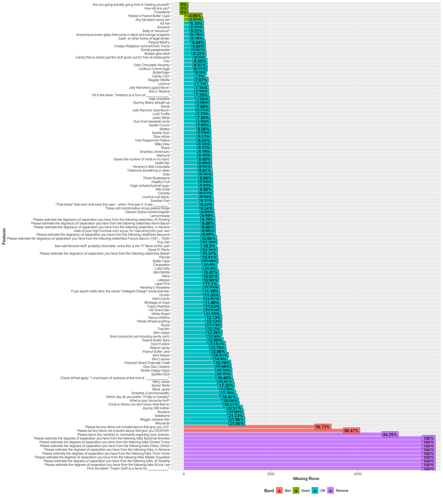

```r
plot_missing(CandyData_2015)
```

```r
# Most of the questions with "Please..." have missing data and the rest there is nothing of value
# to me so I will exclude it. It measures degrees of separation from famous people?
# Also will drop the Taylor Swift question as it's 100% missing values.
CandyData_2015 %>% select(contains("Please"), contains("Taylor")) %>% names()
```

```
##  [1] "Please leave any remarks or comments regarding your choices."
##  [2] "Please list any items not included above that give you JOY."
##  [3] "Please list any items not included above that give you DESPAIR."
##  [4] "Please estimate the degree(s) of separation you have from the following celebrities JK Rowling"
##  [5] "Please estimate the degree(s) of separation you have from the following celebrities JJ Abrams"
##  [6] "Please estimate the degree(s) of separation you have from the following celebrities Beyoncé"
##  [7] "Please estimate the degree(s) of separation you have from the following celebrities Bieber"
##  [8] "Please estimate the degree(s) of separation you have from the following celebrities Kevin Bacon"
##  [9] "Please estimate the degree(s) of separation you have from the following celebrities Francis Bacon (1561 - 1626)"
## [10] "Please estimate the degrees of separation you have from the following folks Bruce Lee"
## [11] "Please estimate the degrees of separation you have from the following folks JK Rowling"
## [12] "Please estimate the degrees of separation you have from the following folks Malala Yousafzai"
## [13] "Please estimate the degrees of separation you have from the following folks Thom Yorke"
## [14] "Please estimate the degrees of separation you have from the following folks JJ Abrams"
## [15] "Please estimate the degrees of separation you have from the following folks Hillary Clinton"
## [16] "Please estimate the degrees of separation you have from the following folks Donald Trump"
## [17] "Please estimate the degrees of separation you have from the following folks Beyoncé Knowles"
## [18] "Fill in the blank: \"Taylor Swift is a force for ___________\""
```

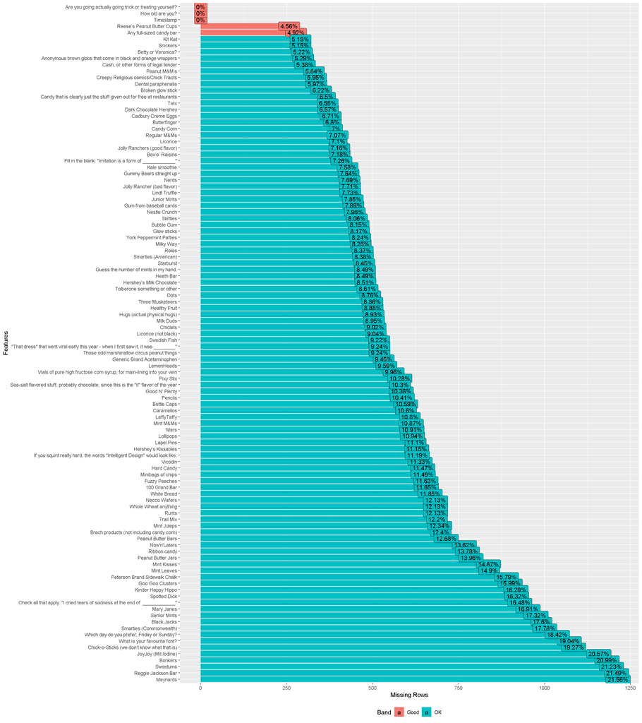

```r
Candy_2015_clean <- CandyData_2015 %>% select(-contains("Please"), -contains("Taylor"))
plot_missing(Candy_2015_clean)
```

Although we still have some missing values, the degree of missing values is “OK” so let’s export this data. Some functions will work better on NA, for this reason else where in the data where there is NA it will be left as is.

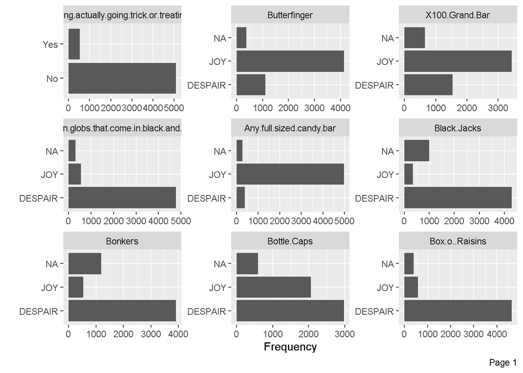

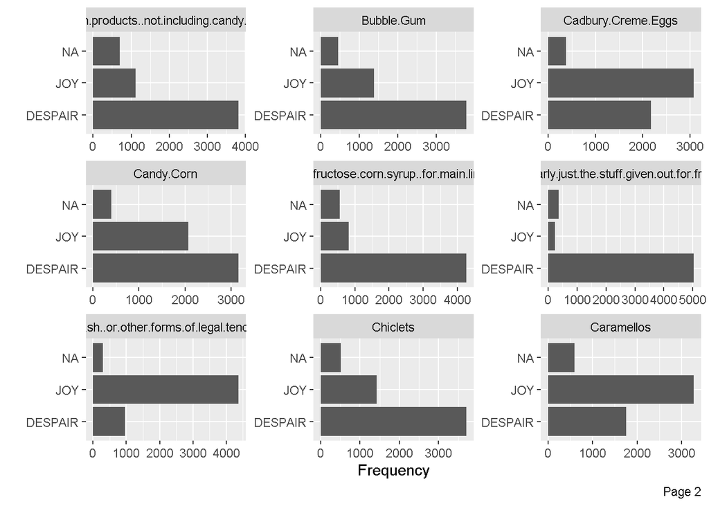

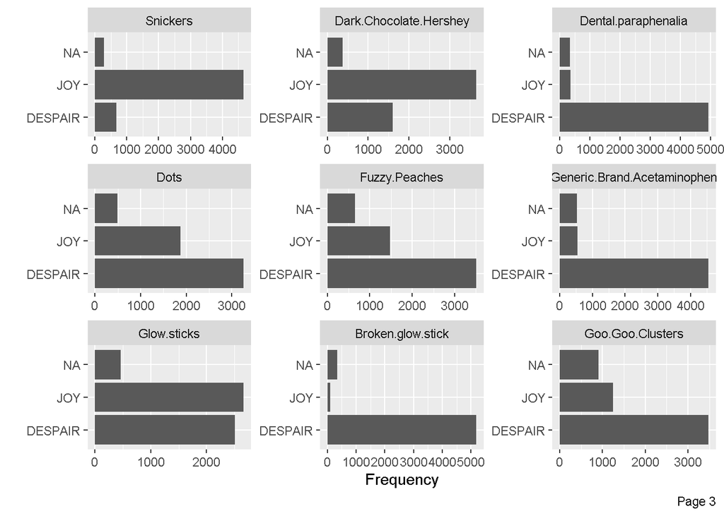

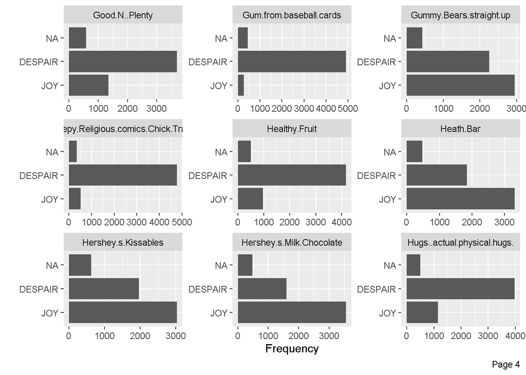

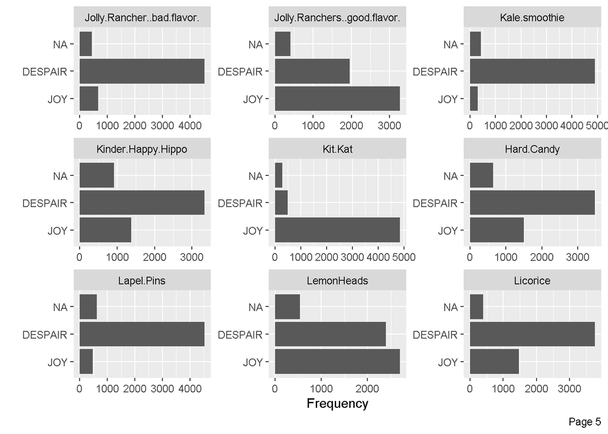

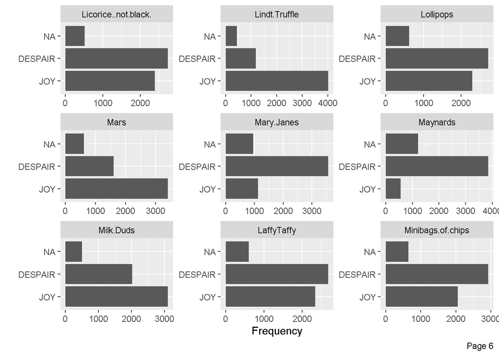

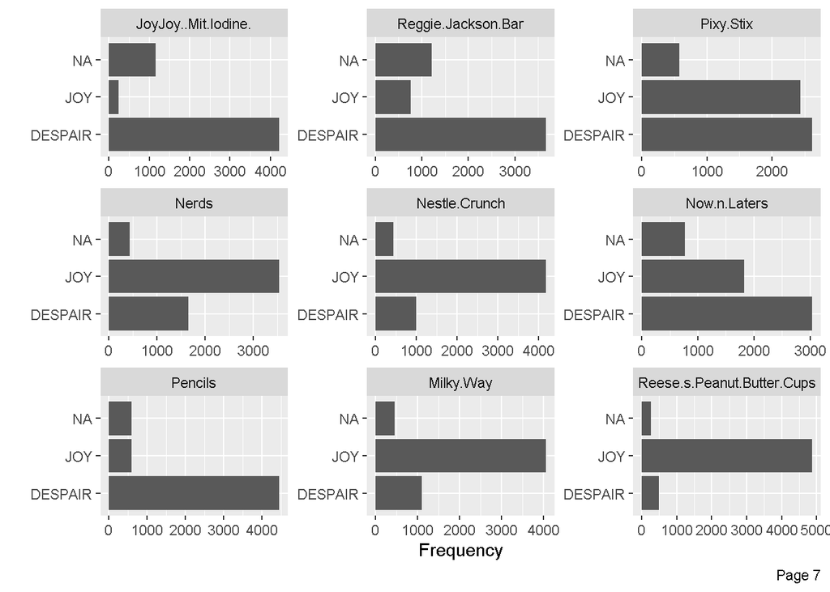

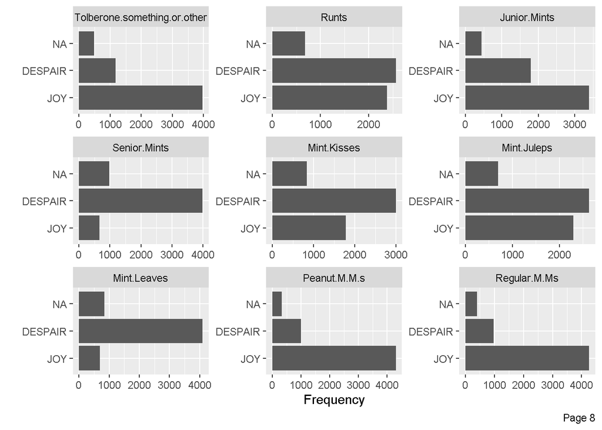

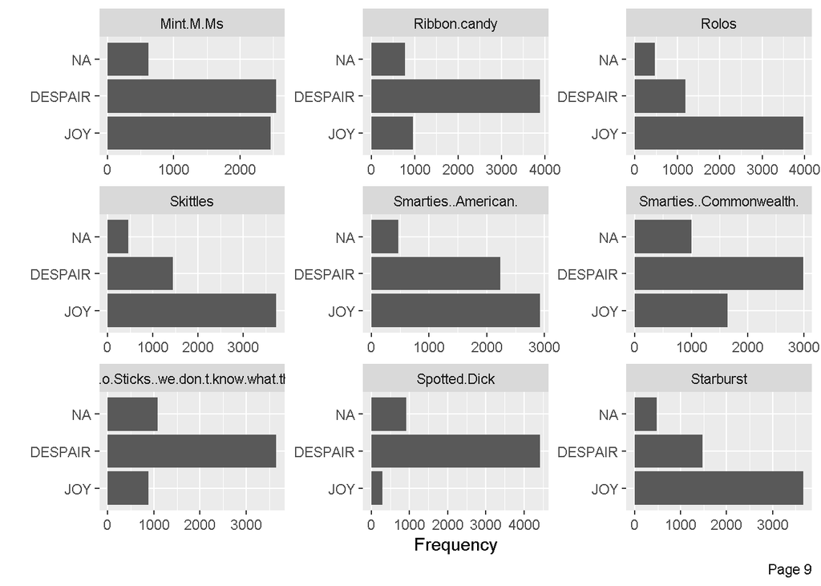

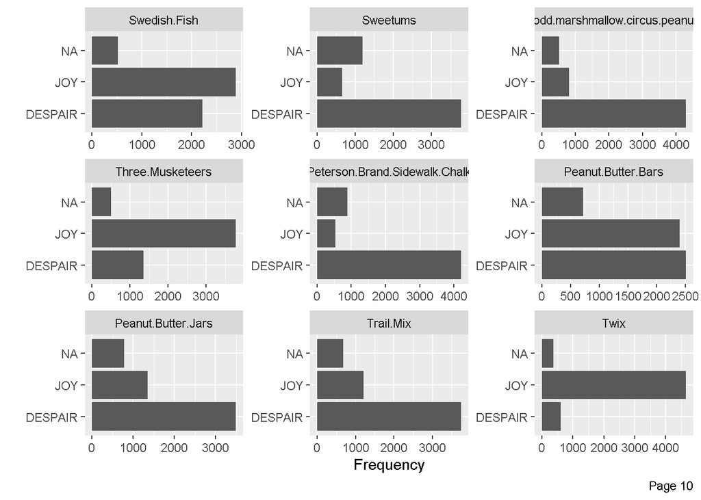

[figure not shown]

```r
plot_bar(Candy_2015_clean %>%
           select(-contains("Guess"), -contains("___"))
         )
```

```r
library(DT)
datatable(head(Candy_2015_clean), rownames = FALSE, filter="top", options = list(pageLength = 5, scrollX=T) )
```

| Timestamp | How old are you? | Are you going actually going trick or treating yourself? | Butterfinger | 100 Grand Bar | Anonymous brown globs that come in black and orange wrappers | Any full-sized candy bar | Black Jacks | Bonkers | Bottle Caps | Box’o’ Raisins | Brach products (not including candy corn) | Bubble Gum | Cadbury Creme Eggs | Candy Corn | Vials of pure high fructose corn syrup, for main-lining into your vein | Candy that is clearly just the stuff given out for free at restaurants | Cash, or other forms of legal tender | Chiclets | Caramellos | Snickers | Dark Chocolate Hershey | Dental paraphenalia | Dots | Fuzzy Peaches | Generic Brand Acetaminophen | Glow sticks | Broken glow stick | Goo Goo Clusters | Good N' Plenty | … |
| --- | --- | --- | --- | --- | --- | --- | --- | --- | --- | --- | --- | --- | --- | --- | --- | --- | --- | --- | --- | --- | --- | --- | --- | --- | --- | --- | --- | --- | --- | --- |
| 2015-10-23T08:46:20Z | 35 | No | JOY |  | DESPAIR | JOY |  |  |  |  | DESPAIR | DESPAIR | DESPAIR |  | DESPAIR | DESPAIR | JOY |  |  | JOY | JOY | DESPAIR | JOY | DESPAIR | DESPAIR | DESPAIR | DESPAIR |  | DESPAIR | … |
| 2015-10-23T08:46:51Z | 41 | No | JOY | JOY | DESPAIR | JOY | DESPAIR | DESPAIR | JOY | DESPAIR | DESPAIR | DESPAIR | DESPAIR | DESPAIR | DESPAIR | DESPAIR | JOY | DESPAIR | DESPAIR | JOY | DESPAIR | DESPAIR | JOY | DESPAIR | JOY | JOY | DESPAIR | DESPAIR | DESPAIR | … |
| 2015-10-23T08:47:34Z | 33 | No | DESPAIR | DESPAIR | DESPAIR | JOY | DESPAIR | DESPAIR | DESPAIR | JOY | DESPAIR | DESPAIR | JOY | JOY | DESPAIR | DESPAIR | JOY | DESPAIR | JOY | JOY | JOY | DESPAIR | DESPAIR | DESPAIR | DESPAIR | DESPAIR | DESPAIR | DESPAIR | DESPAIR | … |
| 2015-10-23T08:47:58Z | 31 | No | JOY | JOY | DESPAIR | JOY | DESPAIR | DESPAIR | JOY | DESPAIR | DESPAIR | DESPAIR | DESPAIR | DESPAIR | DESPAIR | DESPAIR | JOY | DESPAIR | JOY | JOY | JOY | DESPAIR | DESPAIR | DESPAIR | DESPAIR | JOY | DESPAIR | JOY | DESPAIR | … |
| 2015-10-23T08:48:11Z | 30 | No |  | JOY | DESPAIR | JOY |  |  |  |  |  |  |  |  |  |  | JOY |  | JOY |  |  |  | JOY | JOY |  | JOY |  |  |  | … |
| 2015-10-23T08:49:06Z | 38 | No | JOY | JOY | DESPAIR | JOY | DESPAIR | JOY | JOY | DESPAIR | JOY | DESPAIR | DESPAIR | DESPAIR | JOY | DESPAIR | JOY | JOY | JOY | DESPAIR | DESPAIR | DESPAIR | JOY | JOY | DESPAIR | JOY | DESPAIR | JOY | JOY | … |

### Export

```r
library("openxlsx")
write.xlsx(Candy_2015_clean, file = "CandyData_2015_clean.xlsx")
write.csv(Candy_2015_clean, file = "CandyData_2015_clean.csv", row.names = FALSE)

# Since some functions deal with NA a bit differently I won't change all of them, though a simple
# dt[is.na(dt)] <- value
# in R can change all the na values to 0, 0.5, MEH etc.
```

**File for download:**

[CandayData_2015_clean.xlsx](https://raw.githubusercontent.com/DavidRucinski/Heart_health/master/Candy/CandyData_2015_clean.xlsx)

**Raw CSV:**

[CandayData_2015_clean.csv](https://raw.githubusercontent.com/DavidRucinski/Heart_health/master/Candy/CandyData_2015_clean)